# Numpy Reminders:

### Split the data into train/test sets

```python
# Set one year for testing
train = df.iloc[:717]
test = df.iloc[717:]
```

### Fit

```python
model = SARIMAX(train['interpolated'],order=(0,1,3),seasonal_order=(1,0,1,12))
results = model.fit()
results.summary()
```

SARIMAX Results

| Dep. Variable: | interpolated | No. Observations: | 717 |
| --- | --- | --- | --- |
| Model: | SARIMAX(0, 1, 3)x(1, 0, [1], 12) | Log Likelihood | -201.190 |
| Date: | Sun, 03 May 2020 | AIC | 414.379 |
| Time: | 13:44:44 | BIC | 441.821 |
| Sample: | 03-01-1958 | HQIC | 424.976 |
|  | - 11-01-2017 |  |  |
| Covariance Type: | opg |  |  |

|  | coef | std err | z | P>\|z\| | [0.025 | 0.975] |
| --- | --- | --- | --- | --- | --- | --- |
| ma.L1 | -0.3541 | 0.036 | -9.824 | 0.000 | -0.425 | -0.283 |
| ma.L2 | -0.0248 | 0.035 | -0.700 | 0.484 | -0.094 | 0.045 |
| ma.L3 | -0.0869 | 0.033 | -2.606 | 0.009 | -0.152 | -0.022 |
| ar.S.L12 | 0.9997 | 0.000 | 3058.958 | 0.000 | 0.999 | 1.000 |
| ma.S.L12 | -0.8668 | 0.023 | -38.504 | 0.000 | -0.911 | -0.823 |
| sigma2 | 0.0950 | 0.005 | 20.302 | 0.000 | 0.086 | 0.104 |

| Ljung-Box (Q): | 43.95 | Jarque-Bera (JB): | 4.39 |
| --- | --- | --- | --- |
| Prob(Q): | 0.31 | Prob(JB): | 0.11 |
| Heteroskedasticity (H): | 1.15 | Skew: | 0.02 |
| Prob(H) (two-sided): | 0.28 | Kurtosis: | 3.38 |

Warnings:  
[1] Covariance matrix calculated using the outer product of gradients (complex-step).

```python
# Obtain predicted values
start=len(train)
end=len(train)+len(test)-1
predictions = results.predict(start=start, end=end, dynamic=False, typ='levels').rename('SARIMA(0,1,3)(1,0,1,12) Predictions')
```

Passing `dynamic=False` means that forecasts at each point are generated using the full history up to that point (all lagged values).

Passing `typ='levels'` predicts the levels of the original endogenous variables. If we'd used the default `typ='linear'` we would have seen linear predictions in terms of the differenced endogenous variables.

For more information on these arguments visit https://www.statsmodels.org/stable/generated/statsmodels.tsa.arima_model.ARIMAResults.predict.html

```python
# Compare predictions to expected values
for i in range(len(predictions)):
    print(f"predicted={predictions[i]:<11.10}, expected={test['interpolated'][i]}")
```

```
predicted=406.6098861, expected=406.81
predicted=407.8248514, expected=407.96
predicted=408.5788433, expected=408.32
predicted=409.4838247, expected=409.41
predicted=411.0393447, expected=410.24
predicted=411.642275 , expected=411.24
predicted=410.8630395, expected=410.79
predicted=409.1735271, expected=408.71
predicted=407.0731977, expected=406.99
predicted=405.6227532, expected=405.51
predicted=405.892521 , expected=406.0
predicted=407.4256078, expected=408.02
```

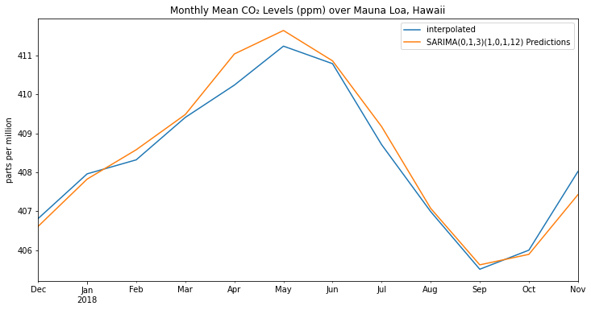

```python
# Plot predictions against known values
title = 'Monthly Mean CO₂ Levels (ppm) over Mauna Loa, Hawaii'
ylabel='parts per million'
xlabel=''

ax = test['interpolated'].plot(legend=True,figsize=(12,6),title=title)
predictions.plot(legend=True)
ax.autoscale(axis='x',tight=True)
ax.set(xlabel=xlabel, ylabel=ylabel);
```

### Evaluate the Model

```python
from sklearn.metrics import mean_squared_error

error = mean_squared_error(test['interpolated'], predictions)
print(f'SARIMA(0,1,3)(1,0,1,12) MSE Error: {error:11.10}')

from statsmodels.tools.eval_measures import rmse

error = rmse(test['interpolated'], predictions)
print(f'SARIMA(0,1,3)(1,0,1,12) RMSE Error: {error:11.10}')
```

```
SARIMA(0,1,3)(1,0,1,12) MSE Error: 0.128018237
SARIMA(0,1,3)(1,0,1,12) RMSE Error: 0.3577963625
```

Remember that in order to understand and intepret de error you need always to look at the data.

```python
test['interpolated'].mean()
```

```
408.3333333333333
```

These are outstanding results!, since a RMSE of 0.35 is tiny compared to 408.333

### Retrain the model on the full data, and forecast the future

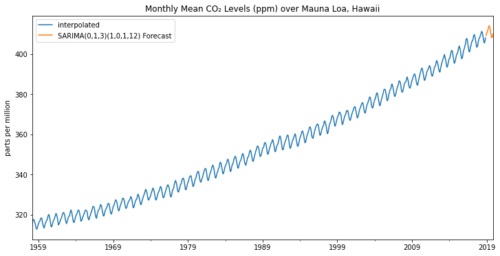

```python
model = SARIMAX(df['interpolated'],order=(0,1,3),seasonal_order=(1,0,1,12))
results = model.fit()
fcast = results.predict(len(df),len(df)+11,typ='levels').rename('SARIMA(0,1,3)(1,0,1,12) Forecast')

# Plot predictions against known values
title = 'Monthly Mean CO₂ Levels (ppm) over Mauna Loa, Hawaii'
ylabel='parts per million'
xlabel=''

ax = df['interpolated'].plot(legend=True,figsize=(12,6),title=title)
fcast.plot(legend=True)
ax.autoscale(axis='x',tight=True)
ax.set(xlabel=xlabel, ylabel=ylabel);
```